# Assignment 2

Chang An Le Harry Jr

2/9/2022

```r
library(jsonlite)
library(tidyverse)
#install.packages("nycflights13")
library(nycflights13)
```

## Question 1 - Retrenched Employees by Industry

1. Use the Data API link on the webpage to find the resource id of this data. Download the full dataset, and name it as r_emp.

```r
root_url = "https://data.gov.sg"
url1 = paste(root_url,
             "/api/action/datastore_search?",
             "resource_id=3d180571-81d3-4834-a759-8374806b731e",
             sep = "")
r_emp_json = fromJSON(url1)
str(r_emp_json)
```

```
## List of 3
##  $ help   : chr "https://data.gov.sg/api/3/action/help_show?name=datastore_search"
##  $ success: logi TRUE
##  $ result :List of 5
##   ..$ resource_id: chr "3d180571-81d3-4834-a759-8374806b731e"
##   ..$ fields     :'data.frame':  6 obs. of  2 variables:
##   .. ..$ type: chr [1:6] "int4" "text" "text" "text" ...
##   .. ..$ id  : chr [1:6] "_id" "quarter" "industry1" "retrench" ...
##   ..$ records    :'data.frame':  100 obs. of  6 variables:
##   .. ..$ _id                   : int [1:100] 1 2 3 4 5 6 7 8 9 10 ...
##   .. ..$ retrench              : chr [1:100] "6170" "560" "2100" "-" ...
##   .. ..$ retrench_term_contract: chr [1:100] "1060" "480" "160" "-" ...
##   .. ..$ quarter               : chr [1:100] "1998-Q1" "1998-Q1" "1998-Q1" "1998-Q1" ...
##   .. ..$ retrench_permanent    : chr [1:100] "5110" "90" "1940" "-" ...
##   .. ..$ industry1             : chr [1:100] "manufacturing" "construction" "services" "others" ...
##   ..$ _links     :List of 2
##   .. ..$ start: chr "/api/action/datastore_search?resource_id=3d180571-81d3-4834-a759-8374806b731e"
##   .. ..$ next : chr "/api/action/datastore_search?offset=100&resource_id=3d180571-81d3-4834-a759-8374806b731e"
##   ..$ total      : int 380
```

```r
r_emp_json$result$`_links`
```

```
## $start
## [1] "/api/action/datastore_search?resource_id=3d180571-81d3-4834-a759-8374806b731e"
##
## $`next`
## [1] "/api/action/datastore_search?offset=100&resource_id=3d180571-81d3-4834-a759-8374806b731e"
```

```r
r_emp = r_emp_json$result$records
total_records = r_emp_json$result$total

times = floor(total_records/100)
for (i in 1:times) {
  url = paste(root_url,
               "/api/action/datastore_search?",
               "offset=", i,
               "00&",
               "resource_id=3d180571-81d3-4834-a759-8374806b731e",
               sep = "")
  r_emp_json = fromJSON(url)
  r_emp = rbind(r_emp, r_emp_json$result$records)
}
dim(r_emp)
```

```
## [1] 380   6
```

With 380 rows and 6 columns, all we need to do is to remove the id column (which is redundant)

```r
r_emp = r_emp[,-(1)]
head(r_emp)
```

```
##   retrench retrench_term_contract quarter retrench_permanent     industry1
## 1     6170                   1060 1998-Q1               5110 manufacturing
## 2      560                    480 1998-Q1                 90  construction
## 3     2100                    160 1998-Q1               1940      services
## 4        -                      - 1998-Q1                  -        others
## 5     5010                    120 1998-Q2               4890 manufacturing
## 6      600                    170 1998-Q2                430  construction
```

```r
dim(r_emp) #to check
```

```
## [1] 380   5
```

2. Data manipulation tasks:

   a. Convert retrench, retrench_term_contract, and retrench_permanent to numeric;

Before conversion:

```r
sapply(r_emp, class)
```

```
##               retrench retrench_term_contract                quarter
##            "character"            "character"            "character"
##     retrench_permanent              industry1
##            "character"            "character"
```

After conversion:

```r
r_emp$retrench = as.numeric(r_emp$retrench)
r_emp$retrench_term_contract = as.numeric(r_emp$retrench_term_contract)
r_emp$retrench_permanent = as.numeric(r_emp$retrench_permanent)
sapply(r_emp,class)
```

```
##               retrench retrench_term_contract                quarter
##              "numeric"              "numeric"            "character"
##     retrench_permanent              industry1
##              "numeric"            "character"
```

2. Convert industry1 to factor;

```r
r_emp$industry1 = as.factor(r_emp$industry1)

sapply(r_emp,class) #to check
```

```
##               retrench retrench_term_contract                quarter
##              "numeric"              "numeric"            "character"
##     retrench_permanent              industry1
##              "numeric"               "factor"
```

3. Compute the summary statistics of all variables in the r_emp data.

```r
summary(r_emp)
```

```
##     retrench    retrench_term_contract   quarter          retrench_permanent
##  Min.   :  10   Min.   :  10.0         Length:380         Min.   :  10
##  1st Qu.: 170   1st Qu.:  40.0         Class :character   1st Qu.: 120
##  Median : 805   Median :  90.0         Mode  :character   Median : 740
##  Mean   :1122   Mean   : 136.2                            Mean   :1028
##  3rd Qu.:1638   3rd Qu.: 160.0                            3rd Qu.:1550
##  Max.   :9100   Max.   :1430.0                            Max.   :7870
##  NA's   :52     NA's   :100                               NA's   :59
##          industry1
##  construction :95
##  manufacturing:95
##  others       :95
##  services     :95
##
##
##
```

3. Explore the dataset by yourself. Answer one question you find interesting about the data. Include the code you used, and summarize (in words) what you found.

Before exploring the dataset, I have chosen to replace all the “NA” values within the dataset to 0. Based on the website, such “NA” values indicate that “Data is negligible or not significant”. Furthermore, since “Data are rounded to the nearest 10”, it would be justifiable to convert the “NA” values to 0 in my opinion.

```r
r_emp[is.na(r_emp)] = 0 #replace all "NA" with 0
r_emp #check if above code was successful
```

```
##     retrench retrench_term_contract quarter retrench_permanent     industry1
## 1       6170                   1060 1998-Q1               5110 manufacturing
## 2        560                    480 1998-Q1                 90  construction
## 3       2100                    160 1998-Q1               1940      services
## 4          0                      0 1998-Q1                  0        others
## 5       5010                    120 1998-Q2               4890 manufacturing
## 6        600                    170 1998-Q2                430  construction
## 7       2130                    150 1998-Q2               1990      services
## 8          0                      0 1998-Q2                  0        others
## 9       4330                    290 1998-Q3               4040 manufacturing
## 10       600                    380 1998-Q3                220  construction
## 11      2680                    310 1998-Q3               2370      services
## 12        10                     10 1998-Q3                  0        others
## 13      5190                    300 1998-Q4               4890 manufacturing
## 14       680                    210 1998-Q4                470  construction
```

[output cut: 366 more lines]

Now, I’d like to find out - which particular years had the highest number of retrenchments in total (regardless of the industry)?

```r
r_emp2 = mutate(r_emp, year = substr(quarter, 1, 4)) #create year column
head(r_emp2) #to check
```

```
##   retrench retrench_term_contract quarter retrench_permanent     industry1 year
## 1     6170                   1060 1998-Q1               5110 manufacturing 1998
## 2      560                    480 1998-Q1                 90  construction 1998
## 3     2100                    160 1998-Q1               1940      services 1998
## 4        0                      0 1998-Q1                  0        others 1998
## 5     5010                    120 1998-Q2               4890 manufacturing 1998
## 6      600                    170 1998-Q2                430  construction 1998
```

```r
r_emp3 = select(r_emp2, retrench, year)
head(r_emp3) #relevant columns only, to check
```

```
##   retrench year
## 1     6170 1998
## 2      560 1998
## 3     2100 1998
## 4        0 1998
## 5     5010 1998
## 6      600 1998
```

```r
r_emp4 = aggregate(r_emp3$retrench, by=list(year = r_emp3$year), FUN=sum)
names(r_emp4)[names(r_emp4) == "x"] = "retrench_total"

arrange(r_emp4, desc(retrench_total))#aggregated dataset based on year
```

```
##    year retrench_total
## 1  1998          32800
## 2  2001          27580
## 3  2020          26140
## 4  2009          23440
## 5  2002          20120
## 6  2016          19170
## 7  2003          17260
## 8  2008          16900
## 9  2015          15600
## 10 1999          15530
## 11 2017          14730
## 12 2006          13090
## 13 2014          12940
## 14 2000          11950
## 15 2013          11550
## 16 2005          11150
## 17 2012          11000
## 18 2018          10740
## 19 2019          10690
## 20 2004          10650
## 21 2011          10020
## 22 2010           9790
## 23 2007           8600
## 24 2021           6520
```

```r
head(r_emp4) #to check output
```

```
##   year retrench_total
## 1 1998          32800
## 2 1999          15530
## 3 2000          11950
## 4 2001          27580
## 5 2002          20120
## 6 2003          17260
```

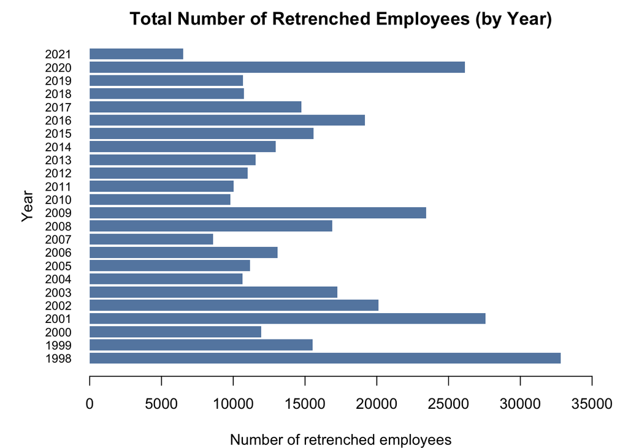

```r
par(las=1) #axis labels always horizontal
par(mar = c(4,5,2,2))
barplot(retrench_total ~ year,
        horiz = TRUE, data = r_emp4,
        ylab = "Year", xlab = "Number of retrenched employees",
        main = "Total Number of Retrenched Employees (by Year)",
        cex.names = 0.8, cex.axis = 1, xlim = c(0,35000), border = NA,
        col=rgb(0.2,0.4,0.6,0.8))
```

From the barplot above, we can tell that the top 5 years with the highest number of retrenched employees are:  
1. 1998 (Asian Financial Crisis)  
2. 2001 (Recession due to dot.com bust)  
3. 2020 (COV1D-19 Outbreak)  
4. 2009 (Aftermath of 2008 Global Financial Crisis)  
5. 2002 (SARS Outbreak)

It is noted that in those particular years, Singapore was experiencing signs of economic recession/downturn/slowdown due to the events mentioned above, which explains the higher numbers of retrenched employees in the country.

## Question 2 - New York Flights data

1. How many flights departed NYC on December 25th 2013?

There are certain rows in the dataset that consist of NA values for dep_time and arr_time. Before we can investigate the dataset, such rows should be removed as they do not represent flights that actually departed NYC, which is the main emphasis of this entire question

```r
full_flights = na.omit(flights) #remove all rows with NA values before investigating dataset
full_flights
```

```
## # A tibble: 327,346 × 19
##     year month   day dep_time sched_dep_time dep_delay arr_time sched_arr_time
##    <int> <int> <int>    <int>          <int>     <dbl>    <int>          <int>
##  1  2013     1     1      517            515         2      830            819
##  2  2013     1     1      533            529         4      850            830
##  3  2013     1     1      542            540         2      923            850
##  4  2013     1     1      544            545        -1     1004           1022
##  5  2013     1     1      554            600        -6      812            837
##  6  2013     1     1      554            558        -4      740            728
##  7  2013     1     1      555            600        -5      913            854
##  8  2013     1     1      557            600        -3      709            723
##  9  2013     1     1      557            600        -3      838            846
## 10  2013     1     1      558            600        -2      753            745
## # … with 327,336 more rows, and 11 more variables: arr_delay <dbl>,
## #   carrier <chr>, flight <int>, tailnum <chr>, origin <chr>, dest <chr>,
## #   air_time <dbl>, distance <dbl>, hour <dbl>, minute <dbl>, time_hour <dttm>
```

```r
#filter out flights that departed NYC on Dec 25, 2013
dec_25_nyc_flights = subset(full_flights, year == 2013 & month == 12 & day == 25)
dec_25_nyc_flights
```

```
## # A tibble: 715 × 19
##     year month   day dep_time sched_dep_time dep_delay arr_time sched_arr_time
##    <int> <int> <int>    <int>          <int>     <dbl>    <int>          <int>
##  1  2013    12    25      456            500        -4      649            651
##  2  2013    12    25      524            515         9      805            814
##  3  2013    12    25      542            540         2      832            850
##  4  2013    12    25      546            550        -4     1022           1027
##  5  2013    12    25      556            600        -4      730            745
##  6  2013    12    25      557            600        -3      743            752
##  7  2013    12    25      557            600        -3      818            831
##  8  2013    12    25      559            600        -1      855            856
##  9  2013    12    25      559            600        -1      849            855
## 10  2013    12    25      600            600         0      850            846
## # … with 705 more rows, and 11 more variables: arr_delay <dbl>, carrier <chr>,
## #   flight <int>, tailnum <chr>, origin <chr>, dest <chr>, air_time <dbl>,
## #   distance <dbl>, hour <dbl>, minute <dbl>, time_hour <dttm>
```

```r
duplicated(dec_25_nyc_flights) #to check for duplicate records
```

[output not shown]

[output cut: 45 more lines]

```r
dim(dec_25_nyc_flights)
```

```
## [1] 715  19
```

There were 715 flights that departed NYC on December 25th, 2013.

2. From the full dataset, flights, extract all flights originated from the JFK airport. Name the new object as data1.

```r
data1 = subset(full_flights, origin == "JFK")
data1
```

```
## # A tibble: 109,079 × 19
##     year month   day dep_time sched_dep_time dep_delay arr_time sched_arr_time
##    <int> <int> <int>    <int>          <int>     <dbl>    <int>          <int>
##  1  2013     1     1      542            540         2      923            850
##  2  2013     1     1      544            545        -1     1004           1022
##  3  2013     1     1      557            600        -3      838            846
##  4  2013     1     1      558            600        -2      849            851
##  5  2013     1     1      558            600        -2      853            856
##  6  2013     1     1      558            600        -2      924            917
##  7  2013     1     1      559            559         0      702            706
##  8  2013     1     1      606            610        -4      837            845
##  9  2013     1     1      611            600        11      945            931
## 10  2013     1     1      613            610         3      925            921
## # … with 109,069 more rows, and 11 more variables: arr_delay <dbl>,
## #   carrier <chr>, flight <int>, tailnum <chr>, origin <chr>, dest <chr>,
## #   air_time <dbl>, distance <dbl>, hour <dbl>, minute <dbl>, time_hour <dttm>
```

3. Select the following six columns: year, month, day, dep_delay, dest, air_time. Replace data1 with the new object with these selected columns.

```r
myvars = c("year", "month", "day", "dep_delay", "dest", "air_time")
data1 = data1[,myvars]
data1
```

```
## # A tibble: 109,079 × 6
##     year month   day dep_delay dest  air_time
##    <int> <int> <int>     <dbl> <chr>    <dbl>
##  1  2013     1     1         2 MIA        160
##  2  2013     1     1        -1 BQN        183
##  3  2013     1     1        -3 MCO        140
##  4  2013     1     1        -2 PBI        149
##  5  2013     1     1        -2 TPA        158
##  6  2013     1     1        -2 LAX        345
##  7  2013     1     1         0 BOS         44
##  8  2013     1     1        -4 ATL        128
##  9  2013     1     1        11 SFO        366
## 10  2013     1     1         3 RSW        175
## # … with 109,069 more rows
```

4. Create a new variable air_time_hrs in data1. The new variable is constructed as: air_time_hrs = air_time / 60

```r
data1 = mutate(data1, air_time_hrs = air_time/60)
data1
```

```
## # A tibble: 109,079 × 7
##     year month   day dep_delay dest  air_time air_time_hrs
##    <int> <int> <int>     <dbl> <chr>    <dbl>        <dbl>
##  1  2013     1     1         2 MIA        160        2.67
##  2  2013     1     1        -1 BQN        183        3.05
##  3  2013     1     1        -3 MCO        140        2.33
##  4  2013     1     1        -2 PBI        149        2.48
##  5  2013     1     1        -2 TPA        158        2.63
##  6  2013     1     1        -2 LAX        345        5.75
##  7  2013     1     1         0 BOS         44        0.733
##  8  2013     1     1        -4 ATL        128        2.13
##  9  2013     1     1        11 SFO        366        6.1
## 10  2013     1     1         3 RSW        175        2.92
## # … with 109,069 more rows
```

5. What is the average departure delay time for all flights in the dataset?

```r
ans = mean(data1$dep_delay, na.rm = TRUE)
ans
```

```
## [1] 12.02361
```

Ans: 12.02361 mins

6. What is the mean departure delay on each day in 2013? (Hint: Use groupby() summarize(), and the pipe operator %>%.)

```r
data12 = data1 %>%
  group_by(year, month, day) %>%
  summarize(mean_dep_delay = mean(dep_delay, na.rm = TRUE))
data12
```

```
## # A tibble: 365 × 4
## # Groups:   year, month [12]
##     year month   day mean_dep_delay
##    <int> <int> <int>          <dbl>
##  1  2013     1     1          12.1
##  2  2013     1     2           8.22
##  3  2013     1     3          13.5
##  4  2013     1     4          10.5
##  5  2013     1     5           7.73
##  6  2013     1     6           6.02
##  7  2013     1     7           3.91
##  8  2013     1     8           3.76
##  9  2013     1     9           5.71
## 10  2013     1    10           2.20
## # … with 355 more rows
```

7. How does departure delay vary with destination airport dest? Which destination airport has the highest delay time of any flight departing from NYC?

```r
data13 = data1 %>%
  group_by(dest) %>%
  summarize(mean_dep_delay_dest = mean(dep_delay))

data13 #to check mean_dep_delay_time across all dest airports, departing from JFK
```

```
## # A tibble: 70 × 2
##    dest  mean_dep_delay_dest
##    <chr>               <dbl>
##  1 ABQ                 13.7
##  2 ACK                  6.45
##  3 ATL                 10.5
##  4 AUS                 14.0
##  5 BHM                  7
##  6 BNA                 18.7
##  7 BOS                 11.6
##  8 BQN                  6.68
##  9 BTV                 10.4
## 10 BUF                 13.2
## # … with 60 more rows
```

```r
arrange(data13, desc(mean_dep_delay_dest)) #CVG is dest with highest mean_dep_delay_time, when considering all flights departing from JFK only
```

```
## # A tibble: 70 × 2
##    dest  mean_dep_delay_dest
##    <chr>               <dbl>
##  1 CVG                  27.3
##  2 EGE                  23.4
##  3 SAT                  22.9
##  4 MCI                  22.6
##  5 CMH                  22.0
##  6 ORD                  21.2
##  7 SDF                  21.2
##  8 MSP                  20.7
##  9 DEN                  20.1
## 10 STL                  20
## # … with 60 more rows
```

Based on the above, the destination airport with the highest delay time of any flight leaving JFK on average is Cincinnati/Northern Kentucky International Airport (CVG), with a reported time of 27.332983 mins.

If we were to investigate a similar statistic for all flights departing from any airport in NYC, however:

```r
full_flights_q7 = full_flights %>%
  group_by(dest) %>%
  summarize(mean_dep_delay_dest = mean(dep_delay))

full_flights_q7 #to check mean_dep_delay_time across all dest airports, departing from any airport in NYC
```

```
## # A tibble: 104 × 2
##    dest  mean_dep_delay_dest
##    <chr>               <dbl>
##  1 ABQ                 13.7
##  2 ACK                  6.45
##  3 ALB                 23.4
##  4 ANC                 12.9
##  5 ATL                 12.4
##  6 AUS                 13.0
##  7 AVL                  8.15
##  8 BDL                 17.7
##  9 BGR                 19.2
## 10 BHM                 29.0
## # … with 94 more rows
```

```r
arrange(full_flights_q7, desc(mean_dep_delay_dest)) #TUL is dest with highest mean_dep_delay_time, when considering all flights departing from any airport in NYC
```

```
## # A tibble: 104 × 2
##    dest  mean_dep_delay_dest
##    <chr>               <dbl>
##  1 TUL                  34.9
##  2 CAE                  33.8
##  3 OKC                  29.2
##  4 BHM                  29.0
##  5 TYS                  28.4
##  6 JAC                  27.5
##  7 DSM                  26.1
##  8 RIC                  23.6
##  9 MSN                  23.5
## 10 ALB                  23.4
## # … with 94 more rows
```

Based on the above, the destination airport with the highest delay time of any flight leaving NYC on average is Tulsa International Airport (TUL), with a reported time of 34.887755 mins.

8. Explore the flights dataset by yourself. Answer one question you find interesting about the data. Include the code you used, and summarize (in words) what you found.

Considering all flights departing from NYC in 2013, which month has the highest departure and arrival delay time on average?

```r
full_flights_agg_dd = aggregate(full_flights$dep_delay, list(full_flights$month), FUN = mean, na.rm = TRUE)
full_flights_agg_dd1 = full_flights_agg_dd %>%
  rename(month = Group.1, mean_dep_delay = x)

arrange(full_flights_agg_dd1, desc(mean_dep_delay)) #aggregated dataset for mean departure delay time by month
```

```
##    month mean_dep_delay
## 1      7      21.522179
## 2      6      20.725614
## 3     12      16.482161
## 4      4      13.849187
## 5      3      13.164289
## 6      5      12.891709
## 7      8      12.570524
## 8      2      10.760239
## 9      1       9.985491
## 10     9       6.630285
## 11    10       6.233175
## 12    11       5.420340
```

```r
full_flights_agg_ad = aggregate(full_flights$arr_delay, list(full_flights$month), FUN = mean, na.rm = TRUE)
full_flights_agg_ad1 = full_flights_agg_ad %>%
  rename(month = Group.1, mean_arr_delay = x)

arrange(full_flights_agg_ad1, desc(mean_arr_delay)) #aggregated dataset for mean arrival delay time by month
```

```
##    month mean_arr_delay
## 1      7     16.7113067
## 2      6     16.4813296
## 3     12     14.8703553
## 4      4     11.1760630
## 5      1      6.1299720
## 6      8      6.0406524
## 7      3      5.8075765
## 8      2      5.6130194
## 9      5      3.5215088
## 10    11      0.4613474
## 11    10     -0.1670627
## 12     9     -4.0183636
```

Based on the 2 aggregated datasets above, it seems that July is the month with the both highest departure and arrival delay times on average when considering all flights departing from NYC in 2013 (excluding NA values from cancelled flights etc). This is an interesting finding considering that July is considered the peak period of summer in New York, so by right the absence of heavy rainfall/snowfall should have reduced the average flight delay times, especially when departing from NYC.

If we were to further investigate the relationship between the mean departure delay and arrival times by month:

```r
combined = merge(full_flights_agg_ad1, full_flights_agg_dd1, by = "month")
combined #merge both datasets by month
```

```
##    month mean_arr_delay mean_dep_delay
## 1      1      6.1299720       9.985491
## 2      2      5.6130194      10.760239
## 3      3      5.8075765      13.164289
## 4      4     11.1760630      13.849187
## 5      5      3.5215088      12.891709
## 6      6     16.4813296      20.725614
## 7      7     16.7113067      21.522179
## 8      8      6.0406524      12.570524
## 9      9     -4.0183636       6.630285
## 10    10     -0.1670627       6.233175
## 11    11      0.4613474       5.420340
## 12    12     14.8703553      16.482161
```

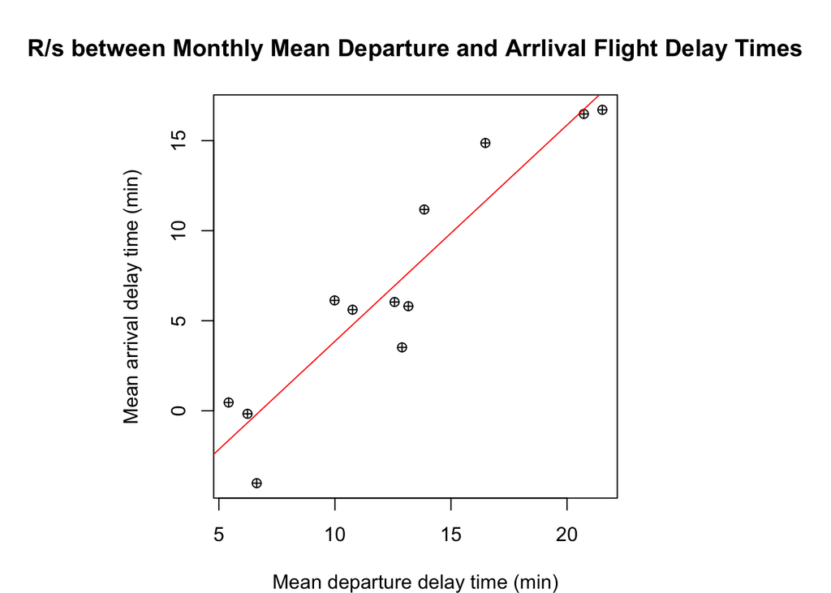

```r
par(mar = c(4,9,4,9))
plot(mean_arr_delay ~ mean_dep_delay, data = combined, pch = 10,
     ylab = "Mean arrival delay time (min)", xlab = "Mean departure delay time (min)",
      main = "R/s between Monthly Mean Departure and Arrlival Flight Delay Times")
abline(lm(mean_arr_delay ~ mean_dep_delay, data = combined), col = "red")
```

From the above plot, it is pretty obvious that the mean departure delay time (by month) shares a positive relationship with the mean departure arrival time of flights from NYC. Logically speaking, this makes sense especially when an increase in departure delay time consequently increases the arrival delay time of a flight on average.

## Question 3 - Demographic score in Peru (Optional)

1. Read the CSV into R and name the object as dem. Describe whether it is considered “tidy data” and explain why.

```r
dem = read_csv("Data/democracy_score.csv")
dem
```

```
## # A tibble: 96 × 10
##    country    YEAR1952 YEAR1957 YEAR1962 YEAR1967 YEAR1972 YEAR1977 YEAR1982
##    <chr>         <dbl>    <dbl>    <dbl>    <dbl>    <dbl>    <dbl>    <dbl>
##  1 Albania          -9       -9       -9       -9       -9       -9       -9
##  2 Argentina        -9       -1       -1       -9       -9       -9       -8
##  3 Armenia          -9       -7       -7       -7       -7       -7       -7
##  4 Australia        10       10       10       10       10       10       10
##  5 Austria          10       10       10       10       10       10       10
##  6 Azerbaijan       -9       -7       -7       -7       -7       -7       -7
##  7 Belarus          -9       -7       -7       -7       -7       -7       -7
##  8 Belgium          10       10       10       10       10       10       10
##  9 Bhutan          -10      -10      -10      -10      -10      -10      -10
## 10 Bolivia          -4       -3       -3       -4       -7       -7        8
## # … with 86 more rows, and 2 more variables: YEAR1987 <dbl>, YEAR1992 <dbl>
```

The above is not considered “tidy data” as year is a numerical variable that should also have its own column.

2. Create a new object dem1 that contains the democracy scores of Peru only.

```r
dem1 = subset(dem, country == "Peru")
dem1
```

```
## # A tibble: 1 × 10
##   country YEAR1952 YEAR1957 YEAR1962 YEAR1967 YEAR1972 YEAR1977 YEAR1982
##   <chr>      <dbl>    <dbl>    <dbl>    <dbl>    <dbl>    <dbl>    <dbl>
## 1 Peru          -2        5       -6        5       -7       -7        7
## # … with 2 more variables: YEAR1987 <dbl>, YEAR1992 <dbl>
```

3. Convert dem1 into a tidy format, using what we learned in Week 6.

```r
names(dem1) = gsub(pattern = "YEAR", replacement = "", x = names(dem1))
dem1
```

```
## # A tibble: 1 × 10
##   country `1952` `1957` `1962` `1967` `1972` `1977` `1982` `1987` `1992`
##   <chr>    <dbl>  <dbl>  <dbl>  <dbl>  <dbl>  <dbl>  <dbl>  <dbl>  <dbl>
## 1 Peru        -2      5     -6      5     -7     -7      7      7     -3
```

```r
dem2 = dem1 %>%
  gather(`1952`:`1992`, key = "year", value = "score")

dem2
```

```
## # A tibble: 9 × 3
##   country year  score
##   <chr>   <chr> <dbl>
## 1 Peru    1952     -2
## 2 Peru    1957      5
## 3 Peru    1962     -6
## 4 Peru    1967      5
## 5 Peru    1972     -7
## 6 Peru    1977     -7
## 7 Peru    1982      7
## 8 Peru    1987      7
## 9 Peru    1992     -3
```